# Generational clashes: Jazz vs Rock vs Hip-Hop

Stefano Longo - UNI: sl4444

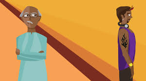

As time goes on, each generation condemns the next generation’s taste in music. Frequent critiques not only revolve around the musical component of new genres but they also target the kind of values associated with them. For example, as Rock rose to popularity in the 50’s, older generations that grew up listening to Jazz, or even Opera, found the new style disgraceful. Few decades later, in the 90’s and early 00’s, the same people that grew up with Rock started describing Hip-Hop in a similar way.

The generation clash is well known, but are the differences across genres as pronounced as they seem? The main point of this report is to try understanding the differences across genres and if Rock was as far from Jazz as Hip-Hop was from Rock.

## Starting from the basics: vocabulary range

Under a musical point of view, newer genres are usually considered “inferior” and less sophisticated. Lyrics, however, while they do not seem to point to an opposite conclusion, do not completely confirm this. In fact, rock artists seem to be the ones using the widest vocabulary, followed by jazz artists and then hip-hop ones. However, this trend might at least partially be driven by the higher amount of rock songs in this database.

| Genre | Number of songs | Number of new words per song |
| --- | --- | --- |
| Jazz | 4122 | 0.28 |
| Rock | 64845 | 0.59 |
| Hip-Hop | 8905 | 0.15 |

## Quality rather than quantity: which 75 words are most frequent in each genre?

The word clouds below use size as a visual representation of frequency. They can intuitively express which words are most used and therefore suggest each genre’s focus. Love truly seems to make the world go round as this word is among most frequent ones across all three genres. More interestingly, however, the preponderance of words like baby and other female epithets in Rock and Hip-Hop songs potentially highlights how these two genres are man dominated. Lastly, the use of coarse words in Hip-Hop is reflect expectations and it is also the reason why I decided to not include as stop words even if the code example suggests otherwise.

# Jazz

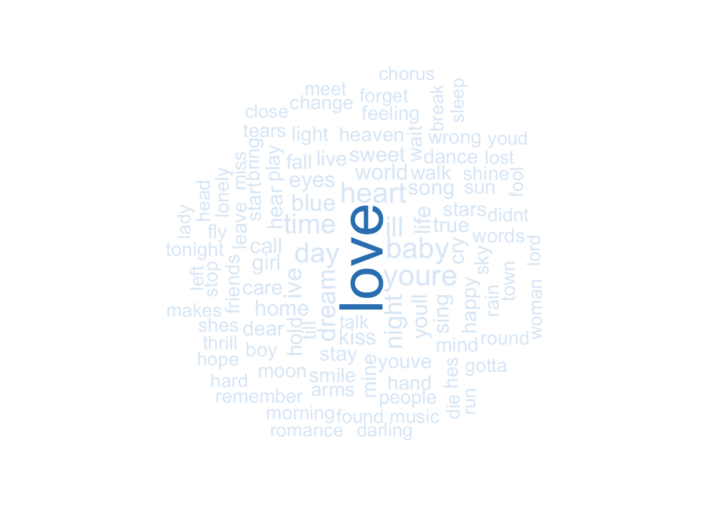

# Rock

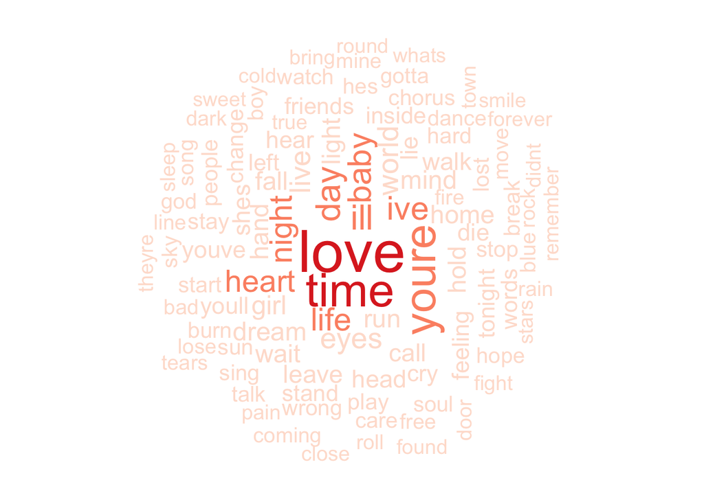

# Hip-Hop

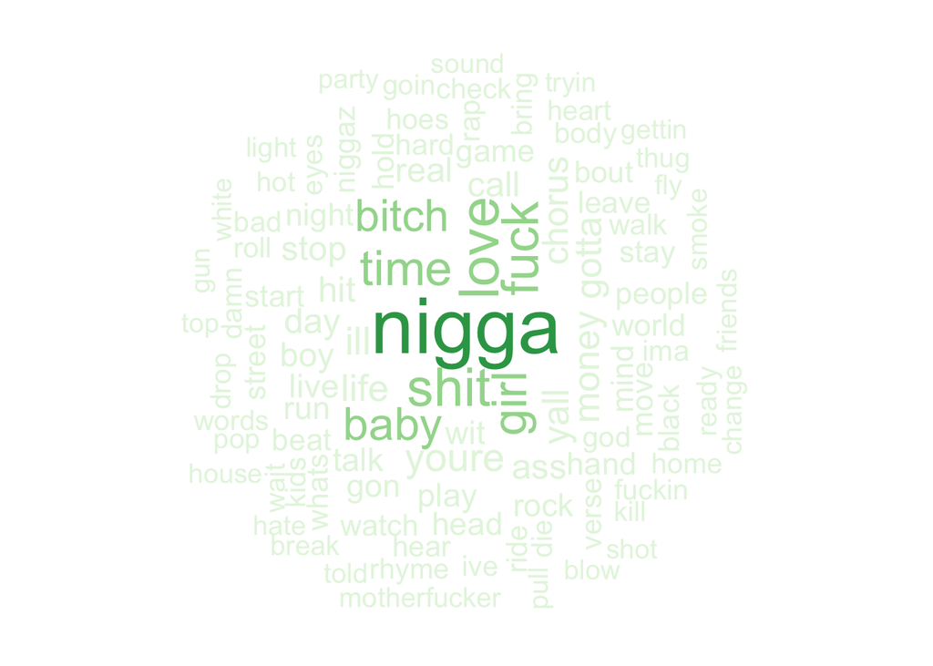

## Cosine similarity as a measure of statistical association

Cosine similarity measures the angular separation of two data vectors measured from zero and it therefore can be used to evaluate the similarity between two vectors. In this case, it is used to compare Jazz and Rock; Rock and Hip-Hop and finally Jazz and Hip-Hop. Alternative measuers of correlation could include the Binary Dice coefficient or the Binary Jaccard coefficient. These three methods are methodologically different but they usually provide very similar results. A more in-depth analysis of these approaches is beyond the scope of the project.

## Sentiment Analysis

Lastly, let’s verify whether the three genres focus on different emotions. Firstly, I categorise words dichotomously into either “positive” or “negative”, thanks to the *sentimentr* package. Assigning a 1 to positive words and a 0 to negative ones, allows me to take and average and estimate where on the spectrum each genre falls. It seems that newer genres have a more negative message than older ones.

| Genre | Sentiment Mean |
| --- | --- |
| jazz | 0.58 |
| rock | 0.37 |
| hiphop | 0.29 |

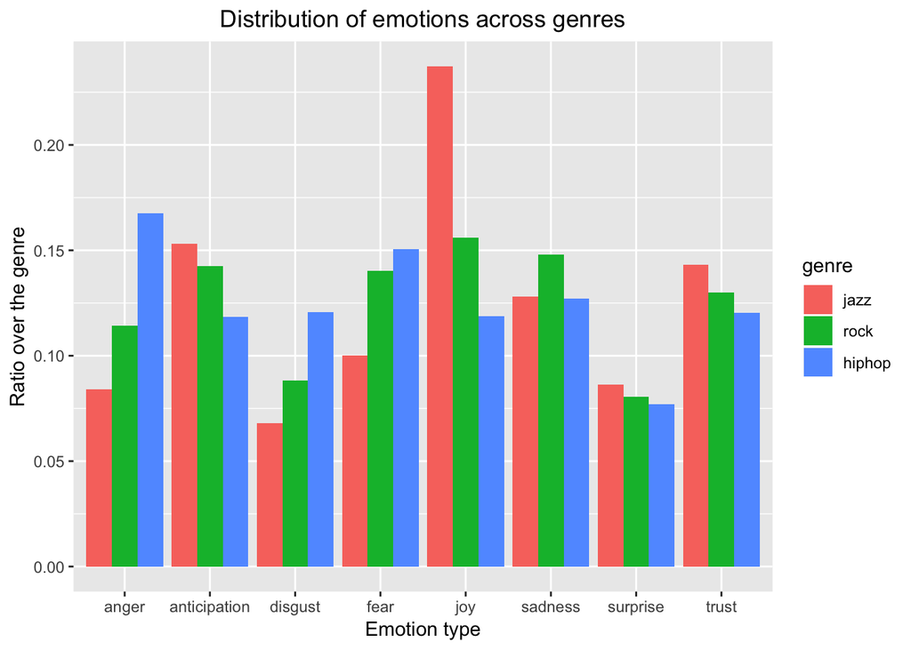